# Git Foundations

## Git Course

**Day 1 topics:**

- Introduction to Version Control System
  - Distributed vs Non-distributed VCS
  - What is Git and where did it come from?
  - Alternatives to Git
  - Cloud-based solutions (Github, Gitlab, BitBucket etc)
- Installation and Configuration
  - Obtaining Git
  - Installing Git
  - Common configuration options
- Key Terminology
  - Clone
  - Staging area
    - Add
  - Commit
  - Push
  - Pull
  - Stash
- working with local repository
  - Creating a repository
  - Checking status
  - Adding files to a repository
  - Committing files
  - Removing staged files
  - Removing committed files
  - Checking logs
- Remote Repository
  - Creating a remote repository
  - Cloning repositories
  - Updating the remote repository from the local
  - Updating the local repository from the remote

## Version Control System (VCS)

- a system that records changes to a file or set of files over time so that you can recall specific versions later.
- `VCS` allows us to:
  - revert selected files back to a previous state
  - compare changes over time
  - see who last modified something that might be causing a problem
  - see who introduced an issue and when, etc.
- Using a VCS means that if things go wrong or lose files, you can recover.
  - with `git`, you get all this for very little overhead.

#### Local Version Control Systems

- copying files into another directory.
  - error prone, easy to forget which directory you’re in and accidentally write to the wrong file or copy over files you don’t mean to.

To deal with this issue, programmers long ago developed local VCSs that had a simple database that kept all the changes to files under revision control.

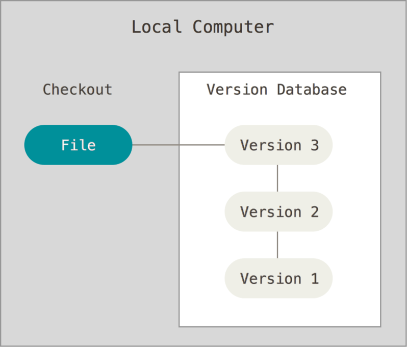

#### Centralized Version Control Systems (CVCS)

- enables collaboration with other developers.
- A good example of such a system is Subversion.
  - They tend to have a single server that contains all the versioned files, and a number of clients that check out files from that central place.
  - For many years, this has been the standard for version control.

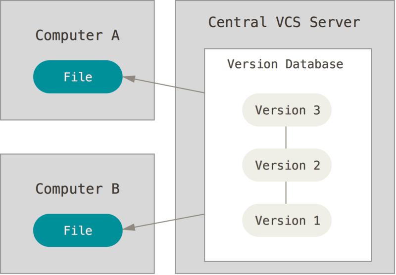

**Advantages over local VCSs:**

- everyone knows to a certain degree what everyone else on the project is doing.
- administrators have fine-grained control over who can do what

Downsides of Centralised version control:

- a single point of failure - the server can go down.
- if the hard disk the central database is on becomes corrupted, and proper backups haven’t been kept, you lose absolutely everything.

#### Distributed Version Control Systems (DVCS)

- In a DVCS (e.g., Git), clients don’t just check out the latest snapshot of the files; rather, they fully mirror the repository, including its full history.
- if any server dies, and these systems were collaborating via that server, any of the client repositories can be copied back up to the server to restore it.
- `Every clone is really a full backup of all the data.`

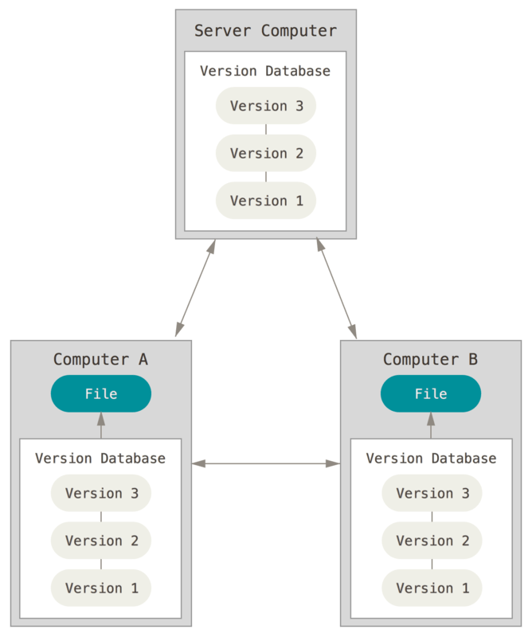

- DVCS systems can have several remote repositories they can work with
- you can collaborate with different groups of people in different ways simultaneously within the same project.

#### Brief History of Git

- Linux was created by `Linus Torvalds`.
- During the early years of the Linux kernel maintenance (1991–2002), changes to the software were passed around as patches and archived files.
- In 2002, the Linux kernel project began using a proprietary DVCS called `BitKeeper`.
- In 2005, the relationship Linux kernel Support Community and the commercial company that developed BitKeeper broke down
  - BitKeeper wasn't free to use any more.
  - The Linux development community (especially `Linus Torvalds` - the creator of Linux) started developing their own tool informed by BitKeeper usage experiences.
- Git was born in 2005,and has evolved and matured to be easy to use.
  - it is the most widely used version control system today
  - it has an incredible branching system for `non-linear` development.

### What is Git?

The main difference between Git and any other VCS (e.g., Subversion) is the way Git thinks about its data. Conceptually, most other systems store information as a list of file-based changes.

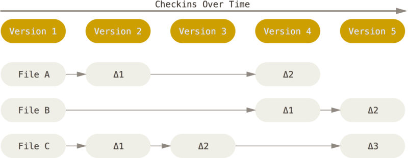

**Git doesn’t store its data this way.**

- Git sees its data like a series of snapshots of a miniature filesystem.
- every time you commit, or save the state of your project, Git basically takes a picture of what all your files look like at that moment and stores a reference to that snapshot.
- For efficiency, if files have not changed, Git doesn’t store the file again, just a link to the previous identical file it has already stored.

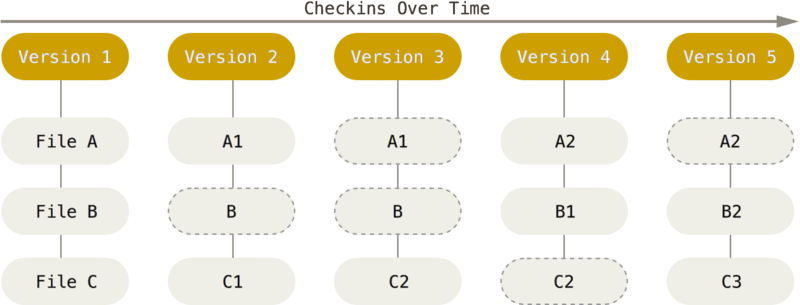

- Git is more like a mini filesystem with some powerful tools built on top of it.

### Most Operations are Local

- Git operations are mostly local to the file system - no information is needed from another computer on your network.
- most operations seem almost instantaneous since you have the entire history of the project on your local disk.
- **Example -**
- to browse the history of the project, Git doesn’t need to go out to the server to get the history and display it for you - it simply reads it directly from your local repo.
- If you want to see the changes introduced between the current version of a file and the file a month ago, Git can look up the file a month ago and do a local difference calculation, instead of having to either ask a remote server to do it or pull an older version of the file from the remote server to do it locally.
- there is very little you can’t do if you’re offline.

#### Git's Integrity

- Everything in Git is `checksummed` before it is stored and is then referred to by that checksum.
  - it’s impossible to change the contents of any file without Git knowing about it.
  - you can’t lose information in transit or get file corruption without Git being able to detect it.
- The mechanism that Git uses for this checksumming is called a `SHA-1` hash.
  - it is a 40-character string composed of hexadecimal characters (0–9, a–f) and calculated based on the contents of a file or directory structure in Git. A SHA-1 hash looks something like this:

24b9da6552252987aa493b52f8696cd6d3b00373

- SHA is a hash for each commit

#### Git generally only adds data

- nearly all actions only add data to the Git database. It is hard to get the system to do anything that is not undoable or to make it erase data in any way.
- you can lose or mess up changes you haven’t committed yet, but after you commit a snapshot into Git, it is very difficult to lose it.

### Three main states

- The main thing to remember about Git
  - Git has `three` main states that your files can be in:
    - `Modified` - you have changed the file but have not committed it yet.
    - `Staged` - you have marked a modified file in its current version to go into your next commit snapshot.
    - `Committed` - the data is safely stored in your local repository.

### 3 main sections of a Git project

- the working tree/directory
- the staging area
- the Git directory/repo

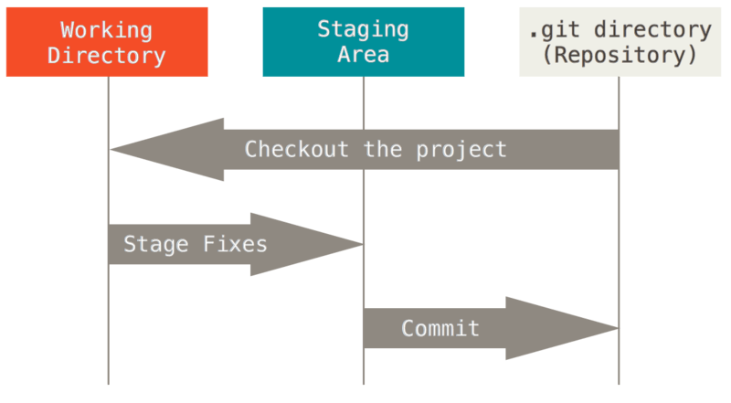

#### Discussion

- The working tree is a single `checkout` of one version of the project. These files are pulled out of the compressed database in the Git directory and placed on disk for you to use or modify.
  - a project can have many files
  - to checkout means to obtain current version of project files from a repo to disk
- The staging area is a file, generally contained in your Git directory, that stores information about what will go into your next commit. Its technical name is the `index`, but the common phrase is `staging area`.
- The `Git directory` or simply `repo` is where Git stores the metadata and object for your project. This is the most important part of Git, and it is what is copied when you `clone` a repository from another computer.

**Basic Git workflow:**

1. Modify/create files in your working tree.
2. `Stage` the changes that you want to be part of your next commit, which adds only those changes to the staging area.
3. Do a commit - takes the files as they are in the staging area and stores that snapshot permanently to your Git directory.

If a particular version of a file is in the Git directory, it’s considered **committed**. If it has been modified and was added to the staging area, it is **staged**. And if it was changed since it was checked out but has not been staged, it is **modified**.

**NEXT ...** To get started - you should know how to open:

- `Terminal` in Linux or macOS
- or `Command Prompt` in Windows.

**Important:**

- Not necessary to memorise every command. Just search for it if you forget.

**The life of your software is recorded from the beginning**

- at any moment you can revert to a previous revision
- the history is browseable, you can inspect any revision
  - when was it done ?
  - who wrote it ?
  - what was changed ?
  - why was it changed
- all the deleted content remains accessible in the history

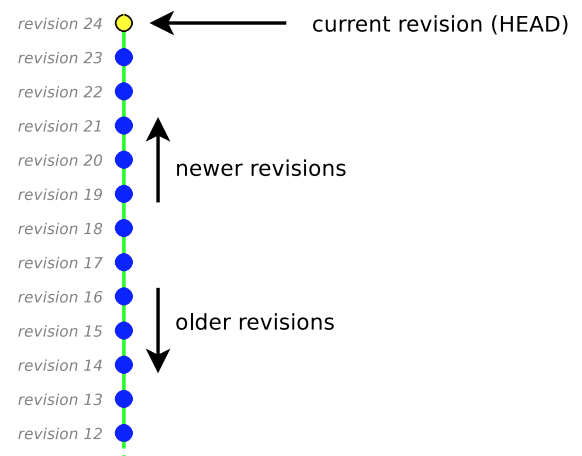

### Installing Git

**On Linux**

- On Fedora (or any closely-related RPM(Red-hat Package Manager)-based distribution, such as RHEL or CentOS), you can use dnf:

`sudo dnf install git-all`

- on a Debian-based distribution, such as Ubuntu:

`sudo apt install git-all`

**Installing on macOS**

- install the Xcode Command Line Tools.
- On Mavericks (10.9) or above you can do this simply by trying to run git from the Terminal the very first time.

`git --version`

If you don’t have it installed already do `brew install git`

- or a macOS Git installer that is maintained and available for download at the Git website, at https://git-scm.com/download/mac.

**Installing on Windows**

- The most official build is available for download on the Git website
- Go to https://git-scm.com/download/win and the download will start automatically.

### Getting started with Git

- useful to customize your Git environment.
- done only once on any given computer
- change them at any time by running through the commands again.
- Git's `git config` lets you get and set configuration variables that control all aspects of how Git looks and operates.

### Your Identity

- set your `user name` and `email address`. This is important because every Git commit uses this information, and it’s immutably baked into the commits you start creating

First - create a local git repository as follows

1. Create a directory called tutorial
2. Change to that directory and issue the command `git init`

**What does `git init` do?**

- creates a branch called `master`
- turns your working directory into a local git repository

**To uninitilize the repo**

- run `rm -rf .git`

### Checking Your Settings

- check your configuration settings by `git config --list` command to list all the settings Git can find at that point
- one can check what Git thinks a specific key’s value is by typing `git config <key>`: e.g. `git config user.name`

You can set the identity details as follows

- `git config --global user.name JohnK`
- `git config --global user.email johnk@gmail.com`

What does this do: `git config --global --replace-all user.name John_K`

- you need to do this only once if you pass the --global option, because then Git will always use that information for anything you do on that system.
- you want to override this with a different name or email address for specific projects, you can run the command without the --global option when you’re in that project.

### Getting Help

- three equivalent ways to get the comprehensive manual page (manpage) help for any of the Git commands:

`git help <verb>` or `git <verb> --help` or `man git-<verb>`

- Example - get the `manpage` help for the `git config` command by running this:

`git help config`

- if you don’t need the full-blown manpage help, but just need a quick refresher on the available options for a Git command, you can ask for the more concise “help” output with the -h option, as in:

`git add -h`

### Getting a Git Repository

**This is an import section, let's take our time on this part**

- Let's cover the most significant `git commands` needed to do most work:
  - configuring and initializing a repository
  - stage and commit changes.
  - selecting staging of files
  - undoing mistakes
  - how to browse the history of your project and view changes between commits
  - how to push and pull from remote repositories.

**Git Repository can be obtained by:**

- by taking a local directory that is currently not under version control, and turning it into a Git repository
- by cloning an existing Git repository .

**Initializing a Repository**

- create a directory in your file system e.g., `mkdir my_project`
- change to that directory e.g., `cd /home/user/my_project` in linux/macos or `cd C:/Users/user/my_project`

**Issue the command** `git init`

#### Reflections

- a new subdirectory named `.git` is created
- it contains all of your necessary repository files — a Git repository skeleton.
- as of now, nothing in your project is tracked yet.

Suppose that you want to version-control existing files:

- begin tracking those files and do an initial commit.
- use `git add` command that specify the files you want to track, followed by a `git commit`:

`git add *.ipynb`

`git commit -m "jupyter notebooks"`

`git push -u origin master`

**How to `clone` an existing repository**

- essentially, getting a copy of an existing Git repository
- Git obtains a full copy of nearly all data that the server has.
- clone ensures that every version of every file for the history of the project is downloaded by default when you run `git clone`.
- if your server disk gets corrupted, you can often use nearly any of the clones on any client to set the server back to the state it was in when it was cloned

The clone command example:

`git clone https://github.com/jmathenge/PythonDev`

#### Reflection on `clone` above

- a directory named PythonDev is created,
- initializes a .git directory inside it
- pulls down all the data for that repository, and checks out a working copy of the latest version.

Visit the **PythonDev** directory that was just created - it has files in there

- you can clone the repository into a directory differently named
  - `git clone https://github.com/jmathenge/PythonDev my_dev`

#### Recording Changes to the Repository

**What do you have so far?**

- a git repository on your local machine.
- a working copy of all of its files.

**Next...**

- start making changes and committing snapshots of those changes into your repository

A file can be in `tracked` or `untracked` states

- Tracked files:
  - in the last snapshot, and any newly staged files; they can be unmodified, modified, or staged.
  - tracked files are files that Git knows about.
- Untracked files:
  - any files in your working directory that were not in your last snapshot and are not in your staging area.
  - after a clone, all of your files will be tracked and unmodified because Git just checked them out and you haven’t edited anything.
- when you edit Git sees them as modified, because you’ve changed them since your last commit.
- you selectively stage these modified files and then commit all those staged changes, and the cycle repeats.

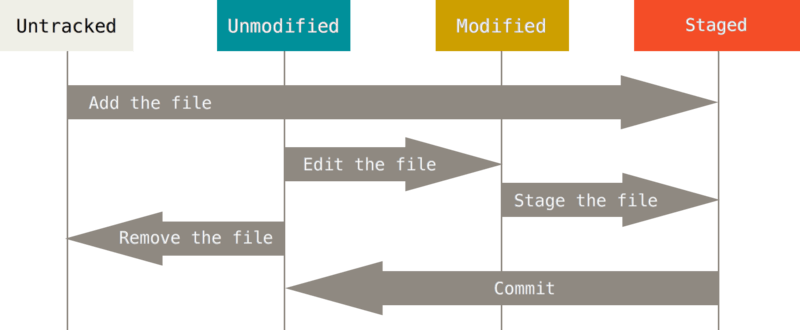

## Check status of your files

`git status`

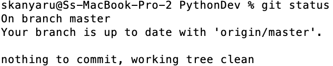

- we have a clean working directory - none of the tracked files are modified.
- Git doesn’t see any untracked files, or they would be listed here.
- we can see that `git status` tells you which branch you’re on and informs you that it has not diverged from the same branch on the server.
- our branch is always master - the default
  - we look at Git Branching later

**Task**

Add a new file to your project, e.g. `Data.txt`. Do it by either:

- `echo "my data">Data.txt` or by `touch Data.txt` or by pasting a new file in your project

Now do `git status`

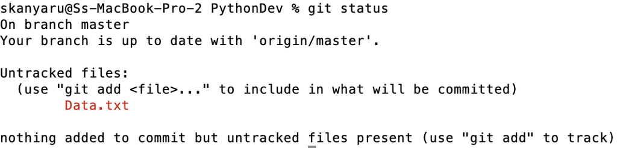

- the **Data.txt** file is untracked
- Untracked means that Git sees a file you didn’t have in the previous snapshot (commit), and which hasn’t yet been staged;
- Git won’t start including it in your commit snapshots until you explicitly tell it to do so. It does this so you don’t accidentally begin including generated binary files or other files that you did not mean to include.

### Tracking New Files

use `git add` command

`git add Data.txt` or you can do `git add *.txt`

Run `git status` and see it is now tracked and ready for commit

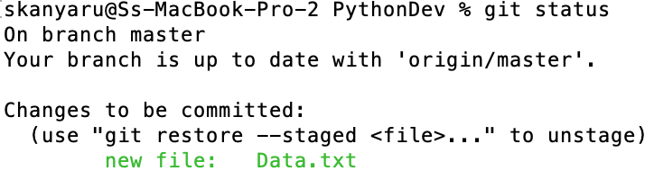

### Modifying & Staging Modified Files

- we change a file that was already tracked. This is our initial, tracked file:

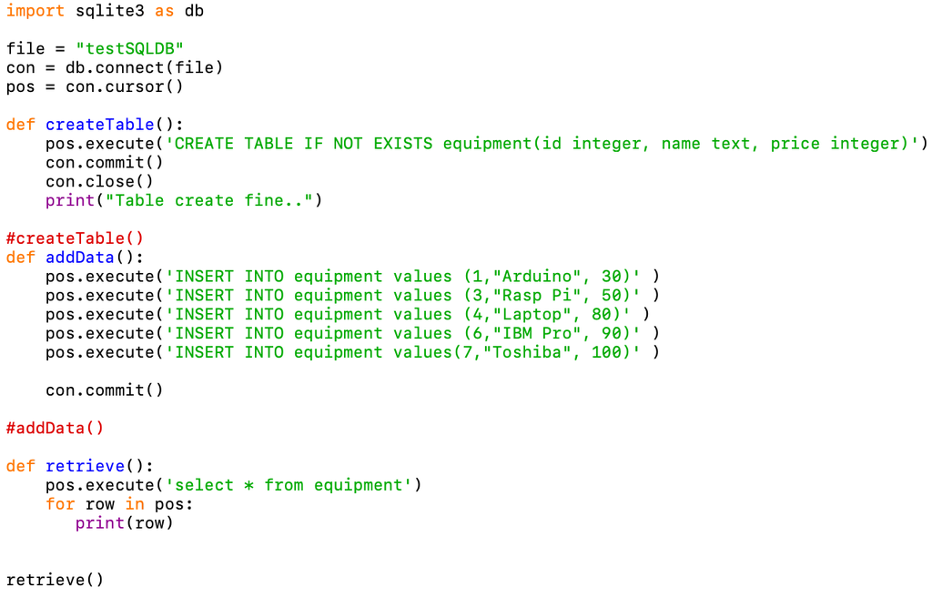

[figure not shown]

`git status` command tells us:

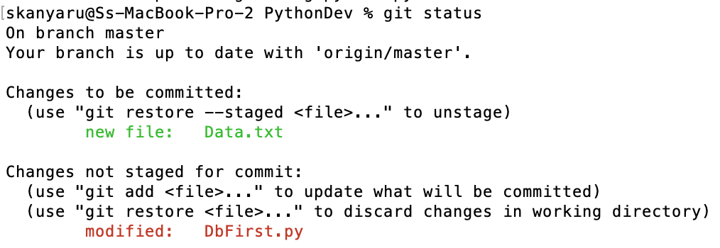

- `Changes not staged for commit` — a file that is tracked has been modified in the working directory but not yet staged.
  - Question - how do you stage it?
    - run `git add`
- `git add` - a multipurpose command
  - use it to begin tracking new files, to stage files, and to do other things like marking merge-conflicted files as resolved. It may be helpful to think of it more as `add precisely` this content to the next commit rather than add this file to the project

    `git add DbFirst.py`

Do `git status` again:

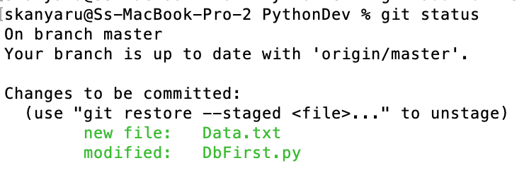

- Both files are staged and will go into your next commit.
- Suppose you remember a change that you want to make in `DbFirst.py` before you commit it. Example, add a multiplication function.

Open the file again, make the change, and you’re ready to commit.

Before committing, run git status one more time:

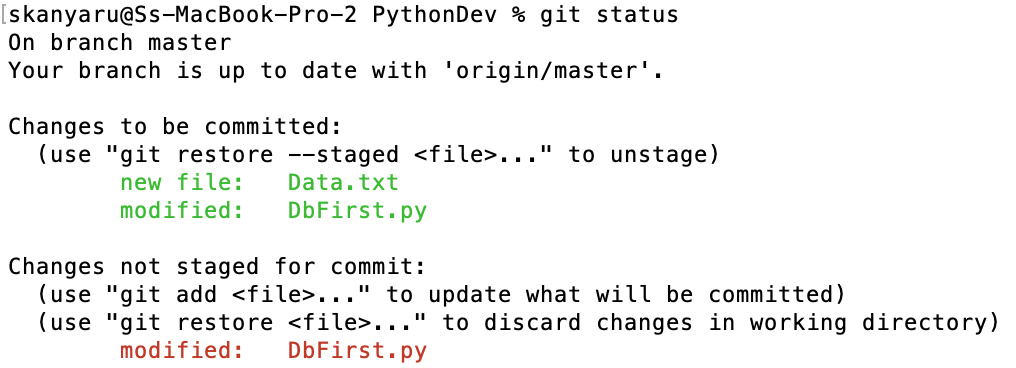

#### Reflection

- `DbFirst.py` is listed as both staged and unstaged.
- Git stages a file exactly as it is when you run the `git add` command.
- If you commit now, the version of `DbFirst.py` as it was when you last ran the `git add` command is how it will go into the commit
- If you modify a file after you run `git add`, you have to run git add again to stage the latest version of the file:

`git add DbFirst.py`

You can check the status again, and all should be ready to commit now.

- do `git status -s` for short status

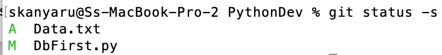

Also see:

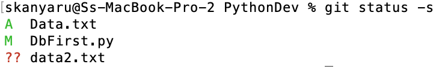

### Reflections

- `??` - denotes new files that are untracked
- `A` - denotes new files that have been added to the staging area
- `M` - denotes modified files.

#### Viewing Staged and Unstaged Changes

- we can know exactly what you changed, not just which files were changed
  - use `git diff` command, which answers the questions:
    - What have you changed but not yet staged?
    - And what have you staged that you are about to commit?
- `git diff` shows the exact lines added and removed.

For example, after commenting out a statement in `DbFirst.py` and changing a function, we run `git diff`:

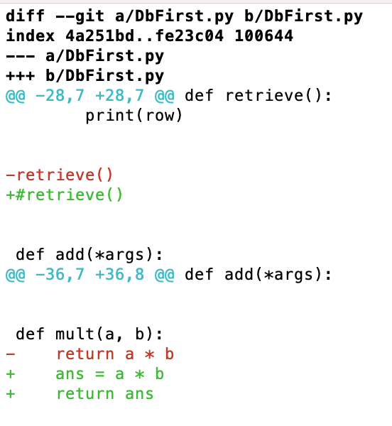

- NB - `git diff` by itself doesn’t show all changes made since your last commit — only changes that are still unstaged.
- If you’ve staged all of your changes, git diff will give you no output.

### Committing Changes

Use the `git commit -m "some message"` to commit your changes.

You can skipp the staging area by `git commit -a -m 'new features'

- basically, stage and commit in one go

### Removing Files

- you have to remove a file from your tracked files (from your staging area) and then commit. - use `git rm command`

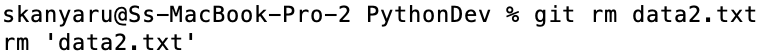

Then git status shows:

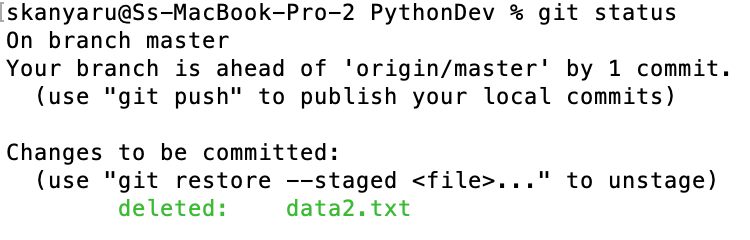

- also removes the file from your working directory so you don’t see it as an untracked file the next time around.

Now commit:

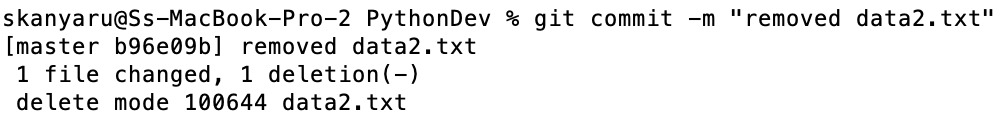

### Viewing the Commit History

- maybe useful after several commits, or if you have cloned a repository with an existing commit history
- look back to see what has happened.
  - use `git log` command.

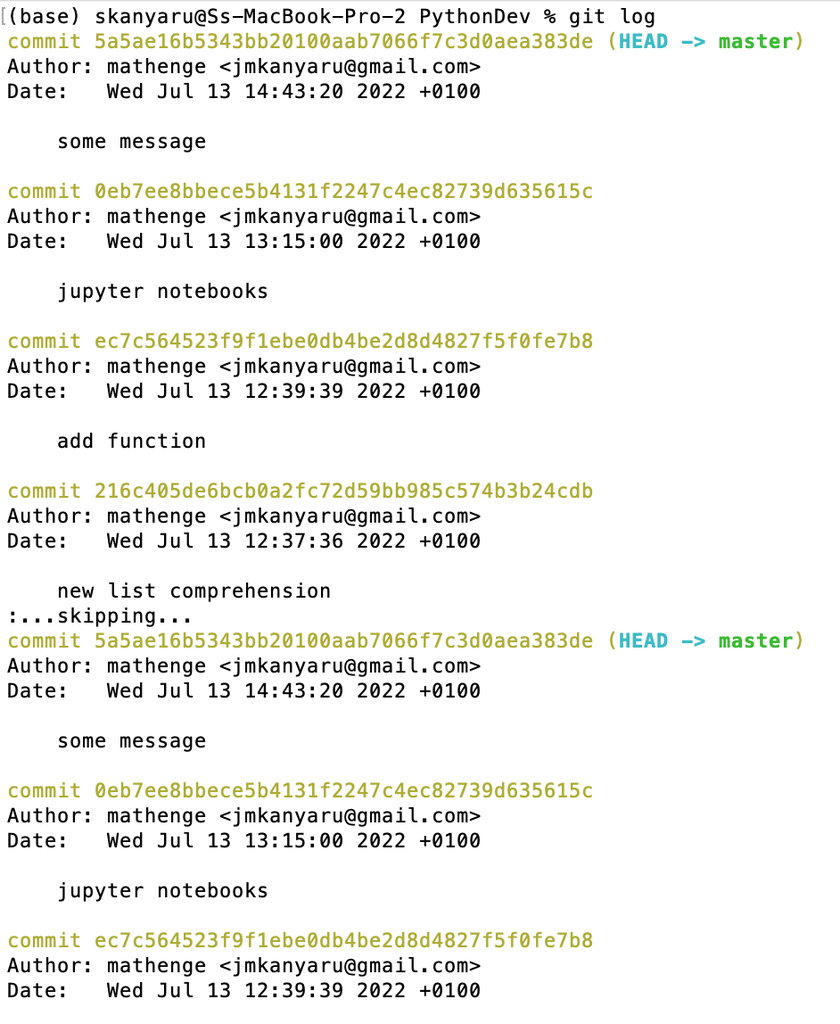

- without arguments, `git log` lists the commits made in that repository in reverse chronological order;
- each commit is listed with its `SHA-1` checksum, the author’s name and email, the date written, and the commit message.
- variety of options to the `git log`
  - `-p` or `--patch` - shows the difference (the patch output) introduced in each commit.
  - one can limit the number of log entries displayed, e.g., `-2` to show only the last two entries.

    see out of `git log -2`

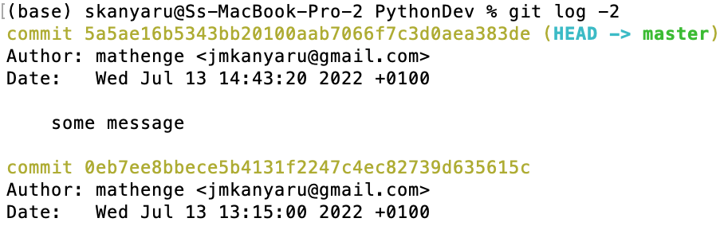

Try `git log -p -2`

- it will display the same information but with a `diff` directly following each entry.
  - useful for code review or to quickly browse what happened during a series of commits that a collaborator has added.

**Summarizing options with git log:**

- for abbreviated stats for each commit use the `git log --stat`

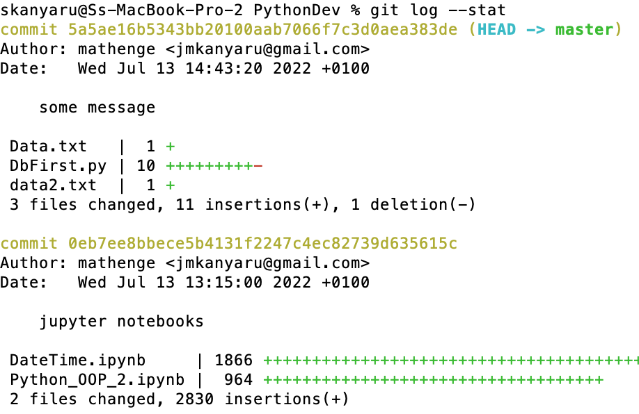

- we see --stat option
  - prints below each commit entry a list of modified files
  - how many files were changed
  - how many lines in those files were added and removed
  - also puts a summary of the information at the end.

### Limiting Log Output

- show only a subset of commits.
- e.g `-2` option displays only the last two commits.
- `-<n>`, where n is any integer will show the last `n` commits.
- How about `time-limiting` options such as `--since` and `--until`
  - example For example:

`git log --since=2.weeks` - **get the list of commits made in the last two weeks**

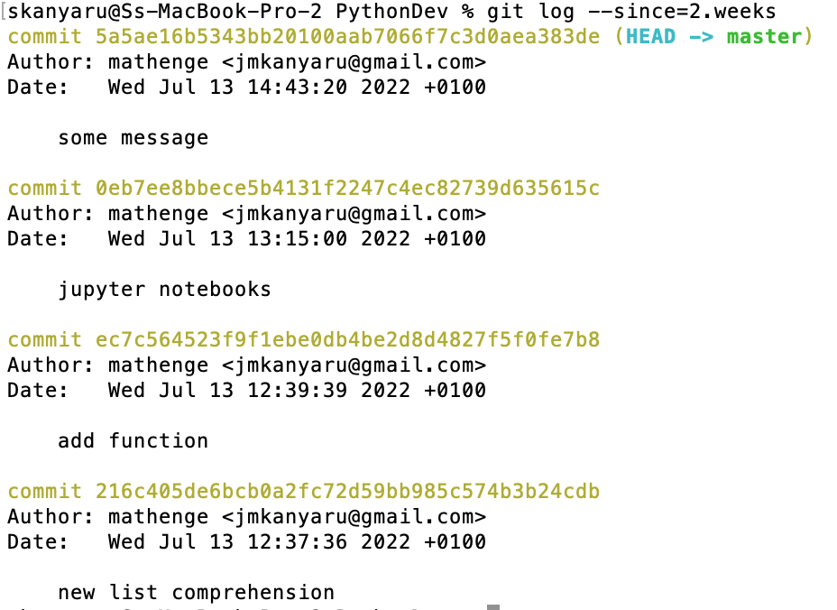

### Undoing Things

- there are some tools for undoing changes.
- **careful** - you can’t always `undo` some of these `undos`.
  - this is one of the few areas in Git where you may lose some work if you do it wrong.
- a common undo takes place when you `commit` too early and forget to `add` some files
- or you get your commit message wrong.
- to redo the commit:
  - make the additional changes you forgot
  - stage them
  - then commit again using the `--amend`

    `git commit --amend`

**Reflections**

- `git commint --amend` - takes staging area and uses it for the commit.
- if no changes were made since last commit, then your snapshot will look exactly the same, and all you’ll change is your commit message.
- You can edit the message - but it overwrites your previous commit.

**Example**

Suppose you commit and then realise you forgot to stage the changes in a file you wanted to add to this commit. E.g, in the file `DbFirst.py`, we add a new function, and then commit before staging. We can solve the issue by:

`git commit -m 'Initial commit'`

`git add DbFirst.py`

`git commit -m 'div function added' --amend`

**The second commit replaces the results of the first**

#### Unstaging a Staged File

- we want to know how to work changes in our working directory.

**Example**

- suppose we have changed two source files and want to commit them as two separate changes
- suppose we accidentally type `git add *` and stage them both.
  - how can you unstage one of the two?

My changes are as follows:

1. In file DbFirst.py, I remove the function `add`
2. In the file dbpandas, I add a function `total`  
   def total(ls): return sum(ls)

Then I do `git add *` which is not what I want to do.

The git status command reminds you:

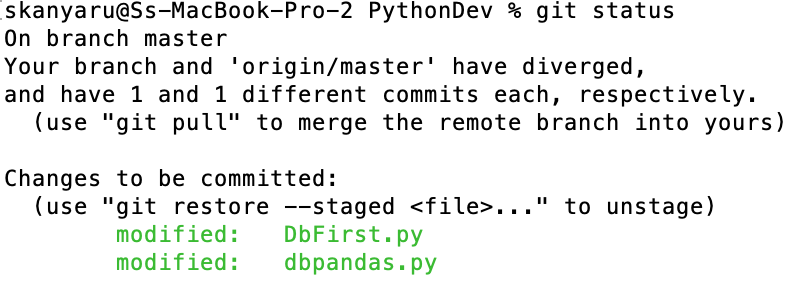

- the `git status` command tells us what other command to use to `unstage`.

We use the command: `git reset HEAD dbpandas.py`

- what is `HEAD`?
  - current active branch
- what would this do `git restore --staged DbFirst.py`?
  - also unstages staged files

After this, check `git status` again.

#### Unmodifying a modified File

- suppose we don't want to keep the changes in `DbFirst.py` or `dbpandas.py` files.
- can we `unmodify` a file to revert it back to what it looked like when you last committed?

**Example:**

- add a function in `dbpandas.py` file.
- check `git status` - this will show the file has been modified
- To unmodify the file, run the command `git checkout -- dbpandas.py`

### Working with remote repositories

- a remote repository is necessary in order to collaborate on a git project
- we shall discover how to manage remote repositories.

**Remote repository** - a version of your project hosted on the Internet or network.

- remote repositories can be `read-only` or `read/write` for you.
- collaborating entails managing a remote repository by:
  - pushing data to it
  - pulling data from it

**Checking which remote repositories you have configured**

- do `git remote`

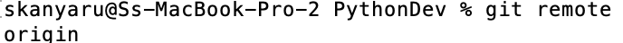

- `git remote` lists shortname of each remote handle you’ve specified.
- if you’ve cloned your repository, you should see `origin` - the default name git gives to the server you cloned from.

**Example**

1. Clone my repository by doing `git clone https://github.com/jmathenge/PythonDev`
2. Then do `cd PythonDev`
3. Now do `git remote`
4. Also do `git remote -v`
- the last command shows you the URLs that Git has stored for the shortname to be used when reading and writing to that remote repository

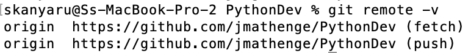

**Question:** What does `git clone` command do?

- it implicitly adds the `origin` remote for you

**We can add a new remote repository explicitly**

- suppose we are in the directory `git_tutorial`.
- First, do a clone like this `git clone https://github.com/jmathenge/PythonDev`
- do `PythonDev` and then check `git remote -v`

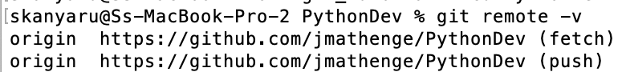

  Origin is added implicitly. Let's add it explicitly with a name of our choice:
  - do `cd ..` and then `git init` if your directory was not initialised
- do `git remote add p_dev https://github.com/jmathenge/PythonDev`

Now do `git remote -v` and see

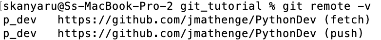

We can now use `p_dev` instead of the whole url.

**Example:**

- to fetch all the information someone, e.g. John has but that you don’t yet have in your repository, run `git fetch p_dev`:

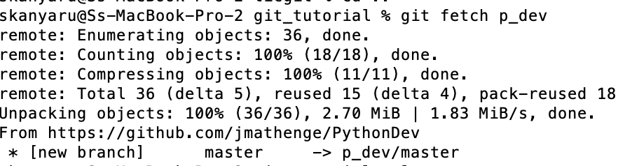

  - John’s master branch is now accessible locally as p_dev/master
  - perhaps you merge it into one of your branches
  - or you can check out a local branch at that point if you want to inspect it
    - more on branches later